© Bản quyền thuộc về Quantopian Inc.  
© Bản quyền sửa đổi thuộc về AI Cafe¹  
Giấy phép [Creative Commons Attribution 4.0](https://creativecommons.org/licenses/by/4.0/legalcode).  
[Khuyến cáo](https://aicafe.one/khuyen-cao/)

# Overfitting (quá khớp)

By Evgenia "Jenny" Nitishinskaya and Delaney Granizo-Mackenzie. Algorithms by David Edwards.

Edited by AI Cafe¹

## Overfitting là gì?

Khi xây dựng một mô hình, chúng ta điều chỉnh cả tham số và mô hình bằng cách khớp với dữ liệu mẫu. Sau đó, chúng ta sử dụng mô hình và các tham số để dự đoán dữ liệu mà chúng ta chưa quan sát. Chúng ta nói rằng một mô hình bị overfit khi nó quá nhạy cảm với nhiễu và các đặc điểm riêng lẻ trong dữ liệu mẫu, do đó không phản ánh đúng quá trình tạo dữ liệu cơ bản.

Để hiểu tại sao điều này xảy ra, chúng ta phải xem xét lượng nhiễu có mặt trong bất kỳ tập dữ liệu nào. Chúng ta có thể coi một tập dữ liệu là $D_{T}$, dữ liệu cơ bản thực sự đến từ bất kỳ quá trình nào mà chúng ta đang cố gắng mô hình hóa, và $\epsilon$, một số nhiễu ngẫu nhiên. Bởi vì những gì chúng ta thấy là $D = D_{T} + \epsilon$, chúng ta có thể khớp mô hình của mình để dự đoán rất chính xác cho $\epsilon$, nhưng không phải cho $D_{T}$.

Điều này là vấn đề bởi vì chúng ta chỉ quan tâm đến việc khớp với mẫu trong chừng mực mà điều đó cung cấp một dự đoán chính xác cho dữ liệu trong tương lai. Hai nguyên nhân chính của overfitting là:

- kích thước mẫu nhỏ, do đó nhiễu và xu hướng không thể phân biệt được
- chọn một mô hình quá phức tạp, vì vậy mà nó cuối cùng bị bóp méo để khớp với nhiễu trong mẫu.

### Ví dụ bằng lời: Quá nhiều quy tắc (Độ phức tạp)

Giả sử bạn có tập dữ liệu sau:

| Kênh TV | Cường độ ánh sáng trong phòng | Sự thích thú |
| --- | --- | --- |
| 1 | 2 | 1 |
| 2 | 3 | 2 |
| 3 | 1 | 3 |

Bạn đang cố gắng dự đoán sự thích thú, vì vậy bạn tạo ra các quy tắc sau:

1. Nếu Kênh TV là 1 và Cường độ ánh sáng là 2, thì Sự thích thú sẽ là 1.
2. Nếu Kênh TV là 2 và Cường độ ánh sáng là 3, thì Sự thích thú sẽ là 2.
3. Nếu Kênh TV là 3 và Cường độ ánh sáng là 1, thì Sự thích thú sẽ là 3.
4. Trong tất cả các trường hợp khác, dự đoán một sự thích thú trung bình là 2.

Đây là một mô hình được định nghĩa rõ ràng cho dữ liệu tương lai, tuy nhiên, trong trường hợp này, giả sử sự thích thú của bạn hoàn toàn phụ thuộc vào kênh TV và không phụ thuộc vào ánh sáng. Bởi vì chúng ta có một quy tắc cho mỗi hàng trong tập dữ liệu của chúng ta, mô hình của chúng ta hoàn toàn có thể dự đoán chính xác trong dữ liệu lịch sử của chúng ta, nhưng sẽ hoạt động kém trong các thử nghiệm thực tế vì chúng ta đang quá khớp với tiếng ồn ngẫu nhiên trong dữ liệu cường độ ánh sáng.

Tổng quát hóa điều này sang cổ phiếu, nếu mô hình của bạn bắt đầu phát triển nhiều quy tắc cụ thể dựa trên các sự kiện trong quá khứ cụ thể, thì gần như chắc chắn là bạn đang quá khớp. Đây là lý do tại sao học máy hộp đen (mạng nơ-ron, v.v.) lại rất nguy hiểm khi không được thực hiện đúng cách.

### Ví dụ: Khớp đường cong

Hiện tượng overfitting dễ dàng nhận thấy nhất khi chúng ta nhìn vào hồi quy đa thức. Dưới đây, chúng ta xây dựng một tập dữ liệu theo dạng bậc hai cộng với nhiễu. Mô hình tuyến tính bị thiếu sót (underfit): các mô hình tuyến tính đơn giản không phù hợp cho tất cả các tình huống, đặc biệt khi chúng ta có lý do để tin rằng dữ liệu là phi tuyến. Đường cong bậc hai có một số lỗi nhưng khớp với dữ liệu rất tốt.

Khi chúng ta khớp một đa thức bậc chín với dữ liệu, lỗi là bằng không - một đa thức bậc chín có thể được xây dựng để đi qua bất kỳ 10 điểm nào - nhưng, nhìn vào đuôi của đường cong, chúng ta biết rằng không thể mong đợi nó dự đoán chính xác các mẫu khác từ cùng một phân phối. Nó khớp hoàn hảo với dữ liệu, nhưng đó là vì nó cũng khớp hoàn hảo với nhiễu, và nhiễu không phải là điều chúng ta muốn mô hình hóa. Trong trường hợp này, chúng ta đã chọn một mô hình quá phức tạp.

```python
import numpy as np
import matplotlib.pyplot as plt
import statsmodels.api as sm
from statsmodels import regression
from numpy import poly1d
```

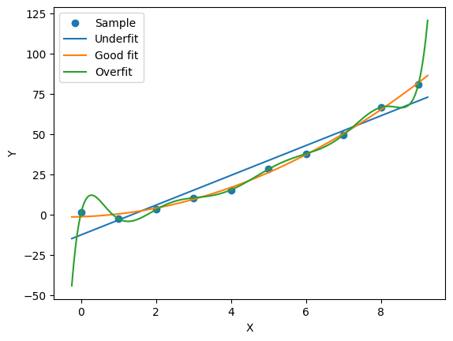

```python
x = np.arange(10)
y = 2*np.random.randn(10) + x**2
xs = np.linspace(-0.25, 9.25, 200)

lin = np.polyfit(x, y, 1)
quad = np.polyfit(x, y, 2)
many = np.polyfit(x, y, 9)

plt.scatter(x, y)
plt.plot(xs, poly1d(lin)(xs))
plt.plot(xs, poly1d(quad)(xs))
plt.plot(xs, poly1d(many)(xs))
plt.ylabel('Y')
plt.xlabel('X')
plt.legend(['Sample', 'Underfit', 'Good fit', 'Overfit']);
```

Khi làm việc với dữ liệu thực, rất ít khi có tình huống mà một đa thức bậc chín là thích hợp: lựa chọn hàm của chúng ta nên phản ánh niềm tin về quá trình tiềm ẩn, và các quá trình trong thế giới thực thường không tuân theo các đường cong đa thức bậc cao. Ví dụ này là gượng ép, nhưng có thể sẽ rất hấp dẫn để sử dụng mô hình bậc hai hoặc bậc ba chỉ để giảm thiểu sai số mẫu.

### Lưu ý: Sự tối giản của mô hình/tham số

Cũng như những mô hình vật lý tinh tế nhất mô tả một lượng lớn thế giới của chúng ta thông qua một vài phương trình, một mô hình giao dịch tốt nên giải thích hầu hết dữ liệu thông qua một vài quy tắc. Bất cứ khi nào bạn bắt đầu có một số quy tắc gần bằng số điểm trong tập dữ liệu của bạn, bạn có thể chắc chắn rằng bạn đang bị quá khớp. Vì các tham số có thể được coi là các quy tắc khi chúng tương đương với việc ràng buộc một mô hình, điều này cũng đúng với các tham số. Ít tham số hơn thì tốt hơn, và tốt hơn là giải thích 60% dữ liệu với 2-3 tham số hơn là 90% với 10 tham số.

### Cảnh giác với sự phù hợp hoàn hảo

Bởi vì gần như luôn có nhiễu trong dữ liệu thực, một sự phù hợp hoàn hảo gần như luôn chỉ ra sự quá khớp. Gần như không thể biết tỷ lệ nhiễu/tín hiệu trong một tập dữ liệu nhất định trong khi bạn đang phát triển mô hình, nhưng hãy sử dụng lý trí của bạn. Liệu các dự đoán có tốt một cách bất ngờ không? Nếu có, thì có lẽ bạn đang quá khớp.

### Ví dụ: Các tham số hồi quy

Làm thế nào để chúng ta biết biến nào nên được đưa vào mô hình? Nếu chúng ta lo lắng về việc bỏ sót điều gì đó quan trọng, chúng ta có thể thử nghiệm với các biến khác nhau và bao gồm tất cả các biến mà chúng ta có thể tìm thấy giúp cải thiện độ phù hợp. Dưới đây, chúng ta hồi quy một tài sản thuộc cùng lĩnh vực với tài sản mà chúng ta đang cố gắng dự đoán giá, và ba tài sản khác không liên quan. Trong khung thời gian ban đầu của chúng ta, chúng ta có thể khớp mô hình chặt chẽ hơn với dữ liệu khi sử dụng nhiều biến hơn là khi chỉ sử dụng một biến.

```python
# Cài thư viện lấy dữ liệu miễn phí
!curl -fsSLO https://raw.githubusercontent.com/algo-stocks/data/master/data.py
```

```
SLR R-squared: 0.2972281916709205
SLR p-value: 6.72093179521647e-21
MLR R-squared: 0.8039722595942002
MLR p-value: 6.29341716928913e-86
```

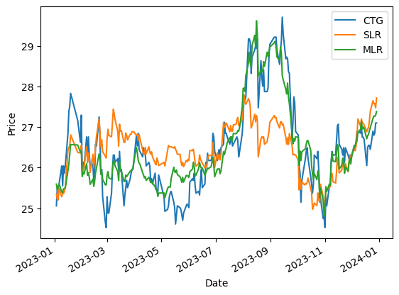

```python
from data import get_prices

start = '2023-01-01'
end = '2024-01-01'

closes = get_prices('CTG', 'BID', 'FPT', 'SSI', 'VIC', start_date=start, end_date=end).dropna()

x1 = closes['BID']
x2 = closes['FPT']
x3 = closes['SSI']
x4 = closes['VIC']
y = closes['CTG']

# Build a linear model using only x1 to explain y
slr = regression.linear_model.OLS(y, sm.add_constant(x1)).fit()
slr_prediction = slr.params.iloc[0] + slr.params.iloc[1]*x1

# Run multiple linear regression using x1, x2, x3, x4 to explain y
mlr = regression.linear_model.OLS(y, sm.add_constant(np.column_stack((x1,x2,x3,x4)))).fit()
mlr_prediction = mlr.params.iloc[0] + mlr.params.iloc[1]*x1 + mlr.params.iloc[2]*x2 + mlr.params.iloc[3]*x3 + mlr.params.iloc[4]*x4

# Compute adjusted R-squared for the two different models
print('SLR R-squared:', slr.rsquared_adj)
print('SLR p-value:', slr.f_pvalue)
print('MLR R-squared:', mlr.rsquared_adj)
print('MLR p-value:', mlr.f_pvalue)

# Plot y along with the two different predictions
y.plot()
slr_prediction.plot()
mlr_prediction.plot()
plt.ylabel('Price')
plt.xlabel('Date')
plt.legend(['CTG', 'SLR', 'MLR']);
```

Tuy nhiên, khi chúng ta sử dụng các tham số ước lượng giống nhau để mô hình hóa một khoảng thời gian khác, chúng ta nhận thấy rằng hai mô hình này hoàn toàn vô dụng. Có vẻ như các mối quan hệ mà chúng ta tìm thấy không nhất quán và chỉ đặc trưng cho khoảng thời gian mẫu ban đầu.

```
SLR R-squared: -2.5329443248535886
MLR R-squared: -3.9469026660259
```

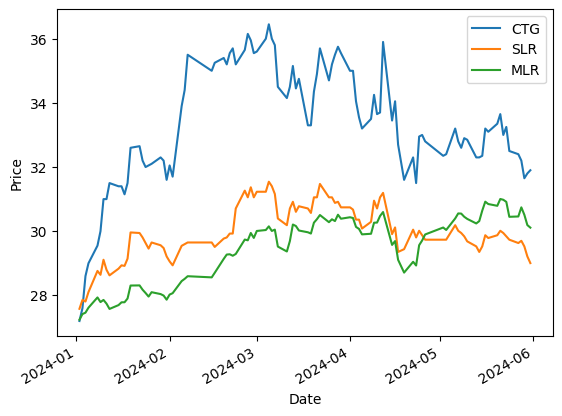

```python
start = '2024-01-01'
end = '2024-06-01'

closes = get_prices('CTG', 'BID', 'FPT', 'SSI', 'VIC', start_date=start, end_date=end).dropna()

x1 = closes['BID']
x2 = closes['FPT']
x3 = closes['SSI']
x4 = closes['VIC']
y = closes['CTG']

# Extend our model from before to the new time period
slr_prediction2 = slr.params.iloc[0] + slr.params.iloc[1]*x1
mlr_prediction2 = mlr.params.iloc[0] + mlr.params.iloc[1]*x1 + mlr.params.iloc[2]*x2 + mlr.params.iloc[3]*x3 + mlr.params.iloc[4]*x4

# Manually compute adjusted R-squared over the new time period

# Adjustment 1 is for the SLR model
p = 1
N = len(y)
adj1 = float(N - 1)/(N - p - 1)

# Now for MLR
p = 4
N = len(y)
adj2 = float(N - 1)/(N - p - 1)

SST = sum((y - np.mean(y))**2)
SSRs = sum((slr_prediction2 - y)**2)
print('SLR R-squared:', 1 - adj1*SSRs/SST)
SSRm = sum((mlr_prediction2 - y)**2)
print('MLR R-squared:', 1 - adj2*SSRm/SST)

# Plot y along with the two different predictions
y.plot()
slr_prediction2.plot()
mlr_prediction2.plot()
plt.ylabel('Price')
plt.xlabel('Date')
plt.legend(['CTG', 'SLR', 'MLR']);
```

Nếu muốn, chúng ta có thể quét toàn bộ không gian của mình để tìm các biến có tương quan với biến phụ thuộc, và xây dựng một mô hình cực kỳ bị quá khớp. Tuy nhiên, trong hầu hết các trường hợp, mối tương quan sẽ là giả tạo, và mối quan hệ sẽ không tiếp tục trong tương lai.

### Ví dụ: Cửa sổ động

Một trong những thách thức trong việc xây dựng một mô hình sử dụng ước lượng tham số động, chẳng hạn như trung bình động hoặc beta động, là lựa chọn chiều dài cửa sổ. Một cửa sổ dài hơn sẽ xem xét các xu hướng dài hạn và ít biến động hơn, nhưng nó cũng sẽ chậm hơn khi xem xét các quan sát mới. Sự lựa chọn chiều dài cửa sổ ảnh hưởng mạnh mẽ đến ước lượng tham số động và có thể thay đổi cách chúng ta nhìn nhận và xử lý dữ liệu. Dưới đây, chúng tôi tính toán các trung bình động của giá cổ phiếu cho các chiều dài cửa sổ khác nhau:

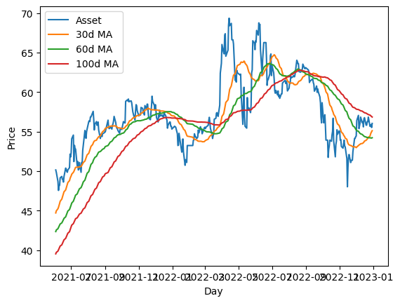

```python
# Load the pricing data for a stock
start = '2021-01-01'
end = '2023-01-01'

prices = get_prices('FPT', start_date=start, end_date=end).FPT

# Compute rolling averages for various window lengths
mu_30d = prices.rolling(window=30).mean()
mu_60d = prices.rolling(window=60).mean()
mu_100d = prices.rolling(window=100).mean()

# Plot asset pricing data with rolling means from the 100th day, when all the means become available
plt.plot(prices[100:], label='Asset')
plt.plot(mu_30d[100:], label='30d MA')
plt.plot(mu_60d[100:], label='60d MA')
plt.plot(mu_100d[100:], label='100d MA')
plt.xlabel('Day')
plt.ylabel('Price')
plt.legend();
```

Nếu chúng ta chọn chiều dài dựa trên cái nào có vẻ tốt nhất - ví dụ, dựa trên hiệu suất của mô hình hoặc thuật toán của chúng ta - thì chúng ta đang bị overfitting. Dưới đây là một thuật toán giao dịch đơn giản mà đặt cược vào việc giá cổ phiếu quay trở lại trung bình động. Chúng ta sử dụng hiệu suất của thuật toán này để đánh giá các chiều dài cửa sổ và tìm ra cái tốt nhất. Tuy nhiên, khi chúng ta xem xét một khoảng thời gian khác, chiều dài cửa sổ này lại không tối ưu. Điều này là do lựa chọn ban đầu của chúng ta đã bị overfitted với dữ liệu mẫu.

```python
# Trade using a simple mean-reversion strategy
def trade(stock, length):

    # If window length is 0, algorithm doesn't make sense, so exit
    if length == 0:
        return 0

    # Compute rolling mean and rolling standard deviation
    rolling_window = stock.rolling(window=length)
    mu = rolling_window.mean()
    std = rolling_window.std()

    # Compute the z-scores for each day using the historical data up to that day
    zscores = (stock - mu)/std

    # Simulate trading
    # Start with no money and no positions
    money = 0
    count = 0
    for i in range(len(stock)):
        # Sell short if the z-score is > 1
        if zscores[i] > 1:
            money += stock[i]
            count -= 1
        # Buy long if the z-score is < 1
        elif zscores[i] < -1:
            money -= stock[i]
            count += 1
        # Clear positions if the z-score between -.5 and .5
        elif abs(zscores[i]) < 0.5:
            money += count*stock[i]
            count = 0
    return money
```

```python
# Find the window length 0-254 that gives the highest returns using this strategy
from IPython.display import clear_output
length_scores = []

for l in range(255):
    print(f'testing window length: {l}')
    score = trade(prices, l)
    length_scores.append(score)
    clear_output(wait=True)

best_length = np.argmax(length_scores)
print('Best window length:', best_length)
```

```
Best window length: 43
```

```python
# Get pricing data for a different timeframe
start2 = '2023-01-01'
end2 = '2025-01-01'
prices2 = get_prices('FPT', start_date=start2, end_date=end2).FPT

# Find the returns during this period using what we think is the best window length
length_scores2 = []

for l in range(255):
    print(f'testing window length {l}')
    score = trade(prices2, l)
    length_scores2.append(score)
    clear_output(wait=True)

print(best_length, 'day window:', length_scores2[best_length])

# Find the best window length based on this dataset, and the returns using this window length
best_length2 = np.argmax(length_scores2)
print(best_length2, 'day window:', length_scores2[best_length2])
```

```
43 day window: 2540.645900000001
211 day window: 31364.614300000027
```

Rõ ràng là phù hợp với dữ liệu mẫu của chúng ta không phải lúc nào cũng mang lại kết quả tốt trong tương lai. Chỉ để cho vui, hãy vẽ biểu đồ các điểm số độ dài được tính từ hai khoảng thời gian khác nhau:

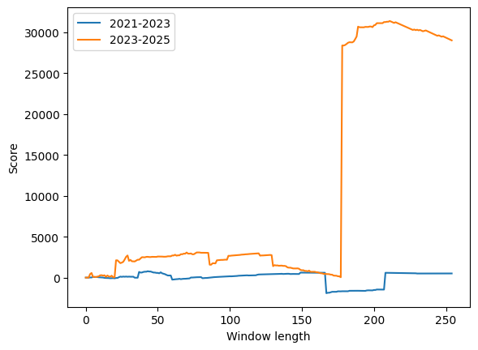

```python
plt.plot(length_scores)
plt.plot(length_scores2)
plt.xlabel('Window length')
plt.ylabel('Score')
plt.legend(['2021-2023', '2023-2025']);
```

Để tránh hiện tượng overfitting, chúng ta có thể sử dụng lý do kinh tế hoặc bản chất của thuật toán của chúng ta để chọn độ dài của cửa sổ. Chúng ta cũng có thể sử dụng bộ lọc Kalman, không yêu cầu chúng ta chỉ định một độ dài; phương pháp này được đề cập trong một bài giảng khác.

## Tránh overfitting

Chúng ta có thể cố gắng tránh overfitting bằng cách lấy mẫu lớn, chọn các mô hình hợp lý và đơn giản, và không chọn lọc các tham số để phù hợp với dữ liệu; nhưng chỉ cần thực hiện hai lần kiểm tra cũng đã là overfitting.

### Kiểm Tra Dữ Liệu Ngoài Mẫu

Để đảm bảo rằng chúng ta không làm hỏng mô hình của mình do overfitting, chúng ta cần kiểm tra dữ liệu ngoài mẫu. Điều này có nghĩa là chúng ta cần thu thập dữ liệu mà chúng ta không sử dụng trong việc xây dựng mô hình, và kiểm tra xem mô hình của chúng ta có tiếp tục hoạt động hay không. Nếu chúng ta không thể thu thập một lượng lớn dữ liệu bổ sung theo ý muốn, chúng ta nên chia mẫu mà chúng ta có thành hai phần, trong đó một phần được dành riêng chỉ để kiểm tra.

### Sai Lầm Thường Gặp: Lạm Dụng Dữ Liệu Ngoài Mẫu

Đôi khi, mọi người sẽ xây dựng một mô hình trên dữ liệu trong mẫu, kiểm tra trên dữ liệu ngoài mẫu, và kết luận rằng nó không hoạt động. Họ sẽ lặp lại quá trình này cho đến khi tìm được một mô hình hoạt động. Điều này vẫn là overfitting, vì bạn đã làm cho mô hình phù hợp với dữ liệu ngoài mẫu bằng cách sử dụng nó nhiều lần, và khi bạn thực sự kiểm tra trên dữ liệu ngoài mẫu thực sự, mô hình của bạn có thể sẽ bị hỏng.

### Kiểm Tra Chéo

Kiểm tra chéo là quá trình chia dữ liệu của bạn thành $n$ phần, sau đó ước lượng các tham số tối ưu cho $n-1$ phần kết hợp và kiểm tra trên phần cuối cùng. Bằng cách làm điều này $n$ lần, mỗi lần cho mỗi phần được giữ lại, chúng ta có thể xác định mức độ ổn định của các ước lượng tham số của chúng ta và mức độ dự đoán của chúng trên dữ liệu không đến từ tập dữ liệu ban đầu.

### Tiêu Chí Thông Tin

Tiêu chí thông tin là một phương pháp thống kê nghiêm ngặt để kiểm tra xem mức độ phức tạp trong mô hình của bạn có xứng đáng với sức mạnh dự đoán bổ sung hay không. Bài kiểm tra này ủng hộ các mô hình đơn giản hơn và sẽ cho bạn biết nếu bạn đang làm phức tạp mô hình mà không có nhiều lợi ích. Một trong những phương pháp phổ biến nhất là [Tiêu chí Thông tin Akaike.](https://en.wikipedia.org/wiki/Akaike_information_criterion)

*Lưu ý: Tài liệu này mang tính chất chia sẻ kiến thức khoa học dữ liệu. Các mã chứng khoán xuất hiện trong tài liệu chỉ mang tính chất minh hoạ, không khuyến nghị đầu tư. Chúng tôi không chịu trách nhiệm trước mọi rủi ro nào do sử dụng tài liệu này.*